# PS 15 Section 8 - Multivariate regression (part 2)

## REMINDERS

1. KNIT AS YOU GO!
2. ALWAYS SET YOUR WORKING DIRECTORY FIRST
3. MAKE SURE YOU KNOW WHAT YOUR VARIABLES ARE (X and Y, ORDER MATTERS)
4. Clear your workspace.

```r
rm(list = ls())
# This removes everything in your environment
```

### 1. Set your working directory and load the congressional elections data (`vote_data.RData`).

```r
#setwd()
load("vote_data.RData")
```

Take a look at what’s inside.

Unit of analysis: incumbent-election, i.e. each row is an congressional incumbent’s performance in an election.

[output not shown]

### 2. How many **unique** incumbents/candidates (“idno”) are in the data-set?

First have a look at your idno variable. Print it out to the console (do NOT knit it):

```r
#vote_data$idno  #delete the #sign to run the code
```

You can immediately tell that the ID numbers are repeated sometimes. We don’t care about the duplicates, so we can use the `unique()` function which returns the non-repeating elements in a vector. The `length()` command tells you how many elements are in vector. Thus, we can combine the two functions to get the **number of unique candidates** in the data-set.

```r
length(unique(vote_data$idno))
```

```
## [1] 1458
```

```r
# Hint: unpack this command and print it out to the console
```

### 3. What is the average number of incumbents in the dataset across the years?

```r
# Average number of incumbents across the years (average times each year showing up in this dataset)
mean(table(vote_data$year))
```

```
## [1] 284.4211
```

Let’s unpack this code. The `table()` provides a count of how many times each year shows up in the dataset. Because each observation here is an incumbent’s election, this essentially creates a table of the number of incumbents for each year.

```r
table(vote_data$year)
```

```
##
## 1972 1974 1976 1978 1980 1982 1984 1986 1988 1990 1992 1994 1996 1998 2000 2002
##  277  285  311  291  303  269  319  287  295  281  229  316  317  300  233  193
## 2004 2006 2008
##  285  297  316
```

We can then average the number of incumbents across the years by applying the `mean()` function to that.

```r
mean(table(vote_data$year))
```

```
## [1] 284.4211
```

### Another example using `table()`.

The variable incwin2 is a dummy variable for whether the incumbent won or lost.

```r
table(vote_data$incwin2)
```

```
##
##    0    1
##  295 5109
```

The `prop.table()` command will give you proportions. Hint: remember that you can type `?prop.table()` in your console to get further information about R commands.

```r
prop.table(table(vote_data$incwin2))
```

```
##
##          0          1
## 0.05458919 0.94541081
```

### 4. Did incumbents outspend their opponents or not?

Let us create a new binary variable that is equal to 1 if the opponent outspent an incumbent and 0 otherwise.

```r
vote_data$outspent <- ifelse(vote_data$oppexp > vote_data$ownexp, 1, 0)
```

Let us unpack this code. The syntax of the `ifelse()` function is `ifelse(condition, if condition is TRUE, if condition is FALSE)`.

Recall that `oppexp` is the expenditure by the opponent, and that `ownexp` is the expenditure by the incumbent.

The condition is always a logical statement. Let us print it to our console and see what happens (again, do NOT knit it):

```r
#vote_data$oppexp > vote_data$ownexp
```

Therefore, if the *condition evaluates to TRUE*, that is, if the opponent outspent the incumbent, our dummy variable `outspent` will be equal to 1. Otherwise, it will be equal to 0.

(In problem set 5 you will use a similar command, but your variable is a factor. Check leture slides for how to handle factors). Hint: you can access more information about **operator/logical operator** via this link https://www.statmethods.net/management/operators.html.

### 5. Do most opponents outspend incumbents?

```r
table(vote_data$outspent)
```

```
##
##    0    1
## 4920  484
```

We can see that most opponents DON’T outspend incumbents (0 = 4920, and 1 = 484).

What percentage of incumbents are outspent by their opponents?

```r
prop.table(table(vote_data$outspent))
```

```
##
##          0          1
## 0.91043671 0.08956329
```

### 6. Run a regression to figure out if outspending results in a higher vote share.

```r
model1 <- lm(ov ~ outspent, data = vote_data)
summary(model1)
```

```
##
## Call:
## lm(formula = ov ~ outspent, data = vote_data)
##
## Residuals:
##      Min       1Q   Median       3Q      Max
## -26.6943  -6.3943  -0.0943   6.0057  30.8757
##
## Coefficients:
##             Estimate Std. Error t value Pr(>|t|)
## (Intercept)  66.0943     0.1315  502.54   <2e-16 ***
## outspent     -9.7700     0.4395  -22.23   <2e-16 ***
## ---
## Signif. codes:  0 '***' 0.001 '**' 0.01 '*' 0.05 '.' 0.1 ' ' 1
##
## Residual standard error: 9.225 on 5402 degrees of freedom
## Multiple R-squared:  0.08382,    Adjusted R-squared:  0.08365
## F-statistic: 494.2 on 1 and 5402 DF,  p-value: < 2.2e-16
```

```r
# ov: the share of two party votes for the incumbent
```

### 7. Do the same but add some controls.

```r
model2 <- lm(ov ~ outspent + moddwnom1 + frosh, data = vote_data)
summary(model2)
```

```
##
## Call:
## lm(formula = ov ~ outspent + moddwnom1 + frosh, data = vote_data)
##
## Residuals:
##     Min      1Q  Median      3Q     Max
## -27.484  -6.352  -0.111   5.881  32.618
##
## Coefficients:
##             Estimate Std. Error t value Pr(>|t|)
## (Intercept)  65.0411     0.2847 228.469  < 2e-16 ***
## outspent     -9.2151     0.4373 -21.073  < 2e-16 ***
## moddwnom1     4.5491     0.6786   6.704 2.23e-11 ***
## frosh        -2.9451     0.3085  -9.546  < 2e-16 ***
## ---
## Signif. codes:  0 '***' 0.001 '**' 0.01 '*' 0.05 '.' 0.1 ' ' 1
##
## Residual standard error: 9.108 on 5400 degrees of freedom
## Multiple R-squared:  0.1072, Adjusted R-squared:  0.1067
## F-statistic: 216.2 on 3 and 5400 DF,  p-value: < 2.2e-16
```

```r
#moddwnom1: Incumbent's voting record (based on dw-nominate).  1 means extreme in the direction of the rest of his party (e.g. an extreme liberal for a Dem), -1 means extreme opposite the direction of his party (e.g.  an extreme liberal for a Rep).
# frosh: freshman incumbent, facing first reelection effort
```

```r
#One method: plug in numbers for each IV to get DV
65.0411+(-9.2151)*1 +4.5491*1+ -2.9451*1  #57.43
```

```
## [1] 57.43
```

```r
#Another method: use predict()
predict(model2, newdata = data.frame(outspent=1, frosh=1,moddwnom1=1))
```

```
##        1
## 57.43004
```

```r
#same result:57.43004
```

### Bonus: Add a list of predicted DVs to your dataset and make a plot with the predicted DV values

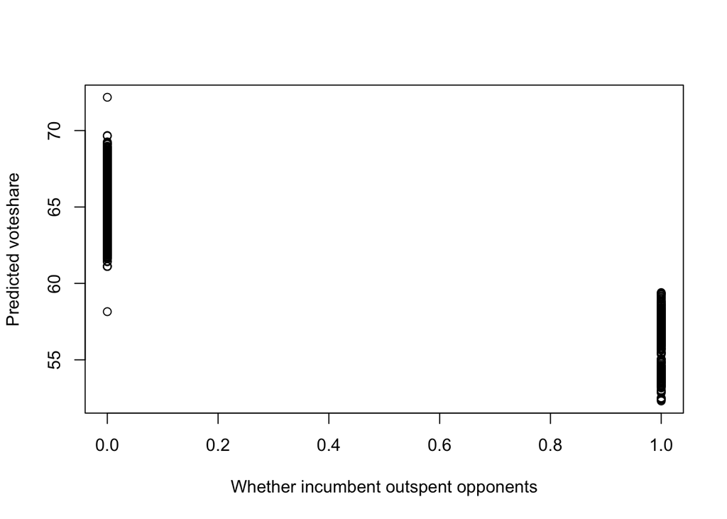

```r
#There are a couple of ways of doing this.
vote_data$fit<-predict(model2)
vote_data$fit2<-fitted.values(model2)
plot(vote_data$fit~vote_data$outspent,xlab="Whether incumbent outspent opponents",ylab="Predicted voteshare")
```